# 4-3.pandasEDA시각화-iplot_학생용

## Pandas 시각화

### EDA를 위한 데이터 시각화

- 데이터 분석을 위해 시각화가 필수임
- 주요 시각화 라이브러리
  - matplotlib, seaborn, plotly

### 가장 최신 기술로, 손쉽게 시각화 익히기

- matplotlib 은 오래된 전통적인 라이브러리
  - 이 한계를 보완하기 위해 seaborn 라이브러리가 출현
  - 오래된 라이브러리로 인터페이스가 복잡함
- 최신 시각화 라이브러리: plotly
  - pandas 기능과 plotly 를 조합해서 최신/가장 빠르게 시각화 가능
  - pandas 데이터프레임.iplot() 같은 형태로 데이터프레임을 바로 그래프로 그릴 수 있음
  - https://plotly.com/python/

> 간편하게 사용하여 데이터 분석 자체에 집중!!!!

### iplot() 으로 시각화 사용하기

- df.iplot(kind=그래프종류) 만으로 그래프를 그릴 수 있으므로, 매우 쉬움
- 단, 관련 자료가 부족하고, 세부 기능 조정에 한계가 있음

가볍게 데이터 확인시는 iplot  
디테일하게 시각화할 시에는 plotly.graph_objects

#### 라이브러리 설치:chart_studio

- chart_studio 는 plotly 로 작성된 그래프를 웹상에서 보여주기 위한 라이브러리
- 최근에는 둘다 설치해야 함
- 꽤 시간이 소요됩니다.

```python
!pip install plotly chart_studio --upgrade
```

```
  Attempting uninstall: plotly
    Found existing installation: plotly 4.14.1
    Uninstalling plotly-4.14.1:
```

```
ERROR: Could not install packages due to an EnvironmentError: [WinError 5] 액세스가 거부되었습니다: 'c:\\programdata\\anaconda3\\etc\\jupyter\\nbconfig\\notebook.d\\plotlywidget.json'
Consider using the `--user` option or check the permissions.
```

#### 라이브러리 설치: cufflinks

- cufflinks
  - pandas로 그래프를 그리기 위한 기능을 plotly 와 연결시키기 위한 라이브러리
  - https://nbviewer.jupyter.org/gist/santosjorge/f3b07b2be8094deea8c6

```python
!pip install cufflinks --upgrade
```

### 라이브러리 로드

- pandas 데이터프레임.iplot() 함수 호출 전에 로드해야 함

```python
import chart_studio.plotly as py #plotly 로드
import cufflinks as cf #데이터프레임과 plotly 연결
cf.go_offline(connected=True) # 쥬피터노트북 offline에서 사용
```

### 테스트 예제

- numpy.random.rand(m, n)
  - m 행, n 열로 0 ~ 1의 균일분포(모든 데이터가 나올 확률이 동일함)에 맞는 랜덤 데이터 생성

```python
import numpy as np
np.random.rand(5)
```

```
array([0.79355384, 0.64855458, 0.90041531, 0.21575308, 0.88011157])
```

```python
import numpy as np
np.random.rand(5, 2)
```

```
array([[0.67143688, 0.65762459],
       [0.44649824, 0.41835359],
       [0.90497564, 0.51498299],
       [0.30314624, 0.67569233],
       [0.94654437, 0.80589411]])
```

```python
import numpy as np
import pandas as pd

df = pd.DataFrame(np.random.rand(10, 2), columns=['A', 'B'])
df.head()
```

|  | A | B |
| --- | --- | --- |
| 0 | 0.293632 | 0.770225 |
| 1 | 0.412496 | 0.075729 |
| 2 | 0.439663 | 0.276474 |
| 3 | 0.691199 | 0.411114 |
| 4 | 0.117282 | 0.232307 |

### 주요 사용법

```
df.iplot(kind=그래프종류)
```

```python
df.iplot()
```

[interactive chart not shown]

```python
pd.read_csv?
```

```python
import pandas as pd
covid_df = pd.read_csv("COVID-19-master/final_df_0119.csv")
covid_df.set_index('Country_Region',inplace=True)
covid_df.head()
```

| Country_Region | 1/22/2020 | 1/23/2020 | 1/24/2020 | 1/25/2020 | 1/26/2020 | 1/27/2020 | 1/28/2020 | 1/29/2020 | 1/30/2020 | 1/31/2020 | ... | 1/09/2021 | 1/10/2021 | 1/11/2021 | 1/12/2021 | 1/13/2021 | 1/14/2021 | 1/15/2021 | 1/16/2021 | 1/17/2021 | 1/18/2021 |
| --- | --- | --- | --- | --- | --- | --- | --- | --- | --- | --- | --- | --- | --- | --- | --- | --- | --- | --- | --- | --- | --- |
| Afghanistan | 0 | 0 | 0 | 0 | 0 | 0 | 0 | 0 | 0 | 0 | ... | 53400 | 53489 | 53538 | 53584 | 53584 | 53775 | 53831 | 53938 | 53984 | 54062 |
| Albania | 0 | 0 | 0 | 0 | 0 | 0 | 0 | 0 | 0 | 0 | ... | 63033 | 63595 | 63971 | 64627 | 65334 | 65994 | 66635 | 67216 | 67690 | 67982 |
| Algeria | 0 | 0 | 0 | 0 | 0 | 0 | 0 | 0 | 0 | 0 | ... | 101913 | 102144 | 102369 | 102641 | 102860 | 103127 | 103381 | 103611 | 103833 | 104092 |
| Andorra | 0 | 0 | 0 | 0 | 0 | 0 | 0 | 0 | 0 | 0 | ... | 8586 | 8586 | 8586 | 8682 | 8818 | 8868 | 8946 | 9038 | 9083 | 9083 |
| Angola | 0 | 0 | 0 | 0 | 0 | 0 | 0 | 0 | 0 | 0 | ... | 18156 | 18193 | 18254 | 18343 | 18425 | 18613 | 18679 | 18765 | 18875 | 18926 |

5 rows × 363 columns

```python
covid_df.loc[['Korea, South','China','Japan']].T.iplot()
```

[interactive chart not shown]

```python
covid_df_T = covid_df.T
covid_df_T[['Korea, South','China','Japan']].iplot()
```

[interactive chart not shown]

### 그래프 종류 알아보기

```python
cf.help()
```

```
Use 'cufflinks.help(figure)' to see the list of available parameters for the given figure.
Use 'DataFrame.iplot(kind=figure)' to plot the respective figure
Figures:
	bar
	box
	bubble
	bubble3d
	candle
	choroplet
	distplot
	heatmap
	histogram
	ohlc
	pie
	ratio
	scatter
	scatter3d
	scattergeo
	spread
	surface
	violin
```

```python
cf.help('bar')
```

```
BAR
Bar Chart
Supports categories and horizontal bar charts


Parameters:
===========
    bargap : float
        Sets the gap between bars
        	[0,1)
    bargroupgap : float
        Sets the gap between groups
        	[0,1)
    barmode : string
        Bar mode
        	group
        	stack
        	overlay
    categories : string
        Name of the column that contains the categories
    orientation : string
        Sets the orientation of the bars.
        	h
        	v
    sortbars : bool
        Sort bars in descending order


    colors : dict, list or string
        Trace color
        	string : applies to all traces
        	list : applies to each trace in the order specified
        	dict : {column:value} for each column in the dataframe
        values
        	colorname : see cufflinks.colors.cnames
        	hex : '#ffffff'
        	rgb : 'rgb(23,50,23)'
        	rgba : 'rgba(23,50,23,.5)
    colorscale : string
        Color scale name
```

[output cut: 224 more lines]

```
            Sets the x axis to be of logarithmic scale
        logy : bool
            Sets the y axis to be of logarithmic scale
        logz : bool
            Sets the z axis to be of logarithmic scale
        xrange : tuple
            Sets the range for the x axis
            	(lower_bound,upper_bound)
        yrange : tuple
            Sets the range for the y axis
            	(lower_bound,upper_bound)

EXAMPLES
    >> cf.datagen.bars(10,5).iplot(kind='bar')
    >> cf.datagen.bars().iplot(kind='bar',orientation='h')
```

iplot()은 빠르고 간편하게 사용하는 용도  
bar와 scatter 주요 사용법 익힘  
필요한 부분을 찾아볼 수 있는 방법을 알아봄

## bar 그래프

```python
df.iplot(kind='bar')
```

[interactive chart not shown]

### 참고:iplot 과 plot

> 다음 예제는 환경에 따라 에러가 날 수 있음
- iplot 은 plotly 라이브러리를 사용해서 interactive 한 그래프를 그리는 기능
- plot 은 matplotlib 라이브러리를 사용해서 static 한 그래프를 그리는 기능

```python
!pip install matplotlib
```

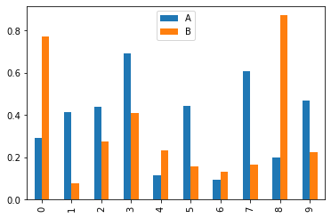

```python
df.plot(kind='bar')
```

```python
df.iplot(kind='bar')
```

[interactive chart not shown]

### 누적 그래프 옵션(barmode)

```python
cf.help('bar')
```

```
BAR
Bar Chart
Supports categories and horizontal bar charts


Parameters:
===========
    bargap : float
        Sets the gap between bars
        	[0,1)
    bargroupgap : float
        Sets the gap between groups
        	[0,1)
    barmode : string
        Bar mode
        	group
        	stack
        	overlay
    categories : string
        Name of the column that contains the categories
    orientation : string
        Sets the orientation of the bars.
        	h
        	v
    sortbars : bool
        Sort bars in descending order


    colors : dict, list or string
        Trace color
        	string : applies to all traces
        	list : applies to each trace in the order specified
        	dict : {column:value} for each column in the dataframe
        values
        	colorname : see cufflinks.colors.cnames
        	hex : '#ffffff'
        	rgb : 'rgb(23,50,23)'
        	rgba : 'rgba(23,50,23,.5)
    colorscale : string
        Color scale name
```

[output cut: 224 more lines]

```
            Sets the x axis to be of logarithmic scale
        logy : bool
            Sets the y axis to be of logarithmic scale
        logz : bool
            Sets the z axis to be of logarithmic scale
        xrange : tuple
            Sets the range for the x axis
            	(lower_bound,upper_bound)
        yrange : tuple
            Sets the range for the y axis
            	(lower_bound,upper_bound)

EXAMPLES
    >> cf.datagen.bars(10,5).iplot(kind='bar')
    >> cf.datagen.bars().iplot(kind='bar',orientation='h')
```

```python
df.iplot(kind='bar',barmode='stack') # barmode='stack' 은 누적 그래프
```

[interactive chart not shown]

### Series 로 그래프 그리기

```python
df['A'].iplot(kind='bar')
```

[interactive chart not shown]

### 가로로 그래프 그리기

```python
cf.help('bar')
```

```
BAR
Bar Chart
Supports categories and horizontal bar charts


Parameters:
===========
    bargap : float
        Sets the gap between bars
        	[0,1)
    bargroupgap : float
        Sets the gap between groups
        	[0,1)
    barmode : string
        Bar mode
        	group
        	stack
        	overlay
    categories : string
        Name of the column that contains the categories
    orientation : string
        Sets the orientation of the bars.
        	h
        	v
    sortbars : bool
        Sort bars in descending order


    colors : dict, list or string
        Trace color
        	string : applies to all traces
        	list : applies to each trace in the order specified
        	dict : {column:value} for each column in the dataframe
        values
        	colorname : see cufflinks.colors.cnames
        	hex : '#ffffff'
        	rgb : 'rgb(23,50,23)'
        	rgba : 'rgba(23,50,23,.5)
    colorscale : string
        Color scale name
```

[output cut: 224 more lines]

```
            Sets the x axis to be of logarithmic scale
        logy : bool
            Sets the y axis to be of logarithmic scale
        logz : bool
            Sets the z axis to be of logarithmic scale
        xrange : tuple
            Sets the range for the x axis
            	(lower_bound,upper_bound)
        yrange : tuple
            Sets the range for the y axis
            	(lower_bound,upper_bound)

EXAMPLES
    >> cf.datagen.bars(10,5).iplot(kind='bar')
    >> cf.datagen.bars().iplot(kind='bar',orientation='h')
```

```python
df.iplot(kind='bar',barmode='stack',orientation='h',bargap=0.1)
```

[interactive chart not shown]

```python
df['A'].iplot(kind='bar',orientation='h')
```

[interactive chart not shown]

## line 그래프

```python
import numpy as np
import pandas as pd

df = pd.DataFrame(np.random.rand(10, 2), columns=['A', 'B'])
df.head()
```

|  | A | B |
| --- | --- | --- |
| 0 | 0.203942 | 0.699937 |
| 1 | 0.073807 | 0.487323 |
| 2 | 0.449647 | 0.610563 |
| 3 | 0.922391 | 0.138375 |
| 4 | 0.387043 | 0.545538 |

### cf.help() 함수로 가볍게 사용법 파악하기

```python
cf.help('scatter')
```

```
SCATTER
Scatter plot
2D chart based in an x and y axis.
Can be a line chart (default) or a set of scatter points (markers)


Parameters:
===========
    bestfit : bool or list
        Displays a best fit line
        If list, then a best fit line will be generated
        for each trace key in the list
    bestfit_colors : dict or list
        Sets the color for each best fit line
        	{key:color} to set the color for each trace
        	[color1, color2...] to set the colors in the specified order
    categories : string
        Name of the column that contains the categories
    connectgaps : bool
        If True, then empty values are connected
    dash : string, list or dict
        Line style
        	string : applies to all traces
        	list : applies to each trace in the order specified
        	dict : {column:value} for each column in the dataframe
        values    :
        	solid
        	dash
        	dashdot
        	dot
    fill : bool
        Fills the trace (area)
    interpolation : string, list or dict
        Interpolation over missing empty line points
        	string : applies to all traces
        	list : applies to each trace in the order specified
        	dict : {column:value} for each column in the dataframe
        values
        	linear
        	spline
```

[output cut: 279 more lines]

```
        logy : bool
            Sets the y axis to be of logarithmic scale
        logz : bool
            Sets the z axis to be of logarithmic scale
        xrange : tuple
            Sets the range for the x axis
            	(lower_bound,upper_bound)
        yrange : tuple
            Sets the range for the y axis
            	(lower_bound,upper_bound)

EXAMPLES
    >> cf.datagen.lines(1).iplot(kind='scatter')
    >> cf.datagen.scatter().iplot(kind='scatter',x='x',y='y',categories='categories',mode='markers')
    >> cf.datagen.lines(1).iplot(kind='scatter',error_type='continuous_percent',error_y=15)
```

```python
df.iplot(kind='scatter') # scatter 가 라인 그래프임
```

[interactive chart not shown]

### 그래프 모양 변경하기

```python
df.iplot(kind='scatter',mode='lines+markers+text')
```

[interactive chart not shown]

### 그래프 채우기

```python
df.iplot(kind='scatter',fill=True)
```

[interactive chart not shown]

```python
cf.help('scatter')
```

```
SCATTER
Scatter plot
2D chart based in an x and y axis.
Can be a line chart (default) or a set of scatter points (markers)


Parameters:
===========
    bestfit : bool or list
        Displays a best fit line
        If list, then a best fit line will be generated
        for each trace key in the list
    bestfit_colors : dict or list
        Sets the color for each best fit line
        	{key:color} to set the color for each trace
        	[color1, color2...] to set the colors in the specified order
    categories : string
        Name of the column that contains the categories
    connectgaps : bool
        If True, then empty values are connected
    dash : string, list or dict
        Line style
        	string : applies to all traces
        	list : applies to each trace in the order specified
        	dict : {column:value} for each column in the dataframe
        values    :
        	solid
        	dash
        	dashdot
        	dot
    fill : bool
        Fills the trace (area)
    interpolation : string, list or dict
        Interpolation over missing empty line points
        	string : applies to all traces
        	list : applies to each trace in the order specified
        	dict : {column:value} for each column in the dataframe
        values
        	linear
        	spline
```

[output cut: 279 more lines]

```
        logy : bool
            Sets the y axis to be of logarithmic scale
        logz : bool
            Sets the z axis to be of logarithmic scale
        xrange : tuple
            Sets the range for the x axis
            	(lower_bound,upper_bound)
        yrange : tuple
            Sets the range for the y axis
            	(lower_bound,upper_bound)

EXAMPLES
    >> cf.datagen.lines(1).iplot(kind='scatter')
    >> cf.datagen.scatter().iplot(kind='scatter',x='x',y='y',categories='categories',mode='markers')
    >> cf.datagen.lines(1).iplot(kind='scatter',error_type='continuous_percent',error_y=15)
```

```python
# df.iplot(kind='scatter', dash = 'dash')
df.iplot(kind='scatter', dash = {'A':'dashdot','B':'solid'})
```

[interactive chart not shown]

### x축, y축, 그래프 타이틀 설정하기

```python
df.iplot(kind='scatter',
            fill=True,
            xTitle='x 축',
            yTitle='y 축',
            title='title')
```

[interactive chart not shown]

### 그래프 테마 변경하기

```python
themes = cf.getThemes()
themes
```

```
['ggplot', 'pearl', 'solar', 'space', 'white', 'polar', 'henanigans']
```

```python
for theme_item in themes:
    df.iplot(kind='scatter',
                theme=theme_item,
                fill=True,
                xTitle='x title',
                yTitle='y title',
                title=theme_item)
```

[interactive chart not shown]

### 그래프의 세부 요소 변경변경

- 주요 요소
  - title, legend, xaxis, yaxis
- 다음 사이트 참고 필요
  - https://plotly.com/python/reference/#layout-title

### 변경 방법

- 타이틀 폰트 및 위치 변경 예
- color값 참고: https://material.io/design/color/the-color-system.html#tools-for-picking-colors

```python
layout = {
    'title':
        {
            'text':'TTT',
            'font': {
                'family': 'consolas',
                'size': 20,
                'color': '#01579B'
            },
            'x': 0.5, # 타이틀 x위치
            'y': 0.85 # 타이틀 y 위치

        }
}
df.iplot(kind='scatter', layout=layout)
```

[interactive chart not shown]

### 그래프 주요 세부 항목 변경 코드

- 그래프 타이틀 변경
- 그래프 x축(xaxis), y축(yaxis) 타이틀 변경
- x축(xaxis), y축(yaxis) tick 단위 변경 및 tick 노출 여부 설정

```python
df.iplot(kind='scatter')
```

```python
layout = {
    'title':
        {
            'text':'Test Graph',
            'font': {
                'size': 15,
                'color': '#37474F'
            },
            'x': 0.5,
            'y': 0.88

        },
    'plot_bgcolor': '#FAFAFA',
    'xaxis': {
        'showticklabels':True,
        'dtick': 2,
        'title': {
            'text':'X axis',
            'font': {
                    'size': 10,
                    'color': '#37474F'
                }
            }
    },
    'yaxis': {
        'showticklabels':True,
        'dtick': 0.1,
        'title': {
            'text':'Y axis',
            'font': {
                    'size': 10,
                    'color': '#37474F'
                }
            }

    }
}
df.iplot(kind='scatter', mode='lines+markers', layout=layout)
```

[interactive chart not shown]

## 서울 기온 변화: 크리스마스 최저/최고 기온 변화

```python
import datetime
import chart_studio.plotly as py #plotly 로드
import cufflinks as cf #데이터프레임과 plotly 연결
cf.go_offline(connected=True) # 쥬피터노트북 offline에서 사용

# 데이터 로드, 인코딩, header,sep 등 필요한 파라미터 사용
df = pd.read_csv('./data/ta_20210103160419.csv',header=7)

df.rename(columns={
    df.columns[2]: '평균기온',
    df.columns[3]: '최저기온',
    df.columns[4]: '최고기온'
},inplace=True)


# 결측 데이터 삭제
df.dropna(inplace=True)

# 날짜 데이터 Str => date 형으로 변환
df['날짜'] = df['날짜'].astype('datetime64[ns]')

#print(df.info())

# 12월 25일 데이터만 추출
chris_df = df[(df["날짜"].dt.month == 12) & (df["날짜"].dt.day == 25)]

# 인덱스를 날짜로 설정
chris_y_df = chris_df.set_index(chris_df['날짜'].dt.year)
```

```python
layout = {
    'title':
        {
            'text':'<b>크리스마스의 최저, 최고 기온의 변화<b>',
            'font': {
                'size': 15,
                'color': '#37474F'
            },
            'x': 0.5,
            'y': 0.88

        },
    'plot_bgcolor': '#FAFAFA',
    'xaxis': {
        'showticklabels':True,
        'dtick': 5,
        'title': {
            'text':'년도',
            'font': {
                    'size': 13,
                    'color': '#37474F'
                }
            },
        'tickangle':45
    },
    'yaxis': {
        'showticklabels':True,
        'dtick': 5,
        'title': {
            'text':'기온',
            'font': {
                    'size': 13,
                    'color': '#37474F'
                }
            }

    }
}
```

```python
chris_y_df[['최저기온','최고기온']].iplot(kind='scatter',layout=layout)
```

[interactive chart not shown]